# Week 2—Assignment

# Recreate a graphic based on the readings from Chapter 3

This asignment asked you to reproduce one of the plots from the *Exercies 3.6.1* in **R for Data Science**

Each of these charts is shown below. There may be other ways to recreate the graphics.

## Required Packages

```r
library(tidyverse)
```

## Graph 1—Top Left

Starting with the top left graphic:

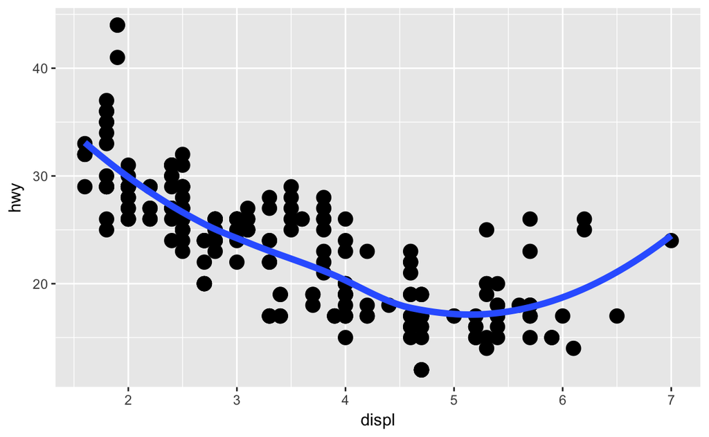

```r
ggplot(data = mpg) +
  geom_point(mapping = aes(x= displ, y = hwy), size = 4) +
  geom_smooth(mapping = aes(x= displ, y = hwy), size = 2, se = FALSE)
```

The main changes in this graphic are the changes to the default size of the datapoints and the width of the line.

I can reduce the amount of typing by including the file information in the ggplot() function.

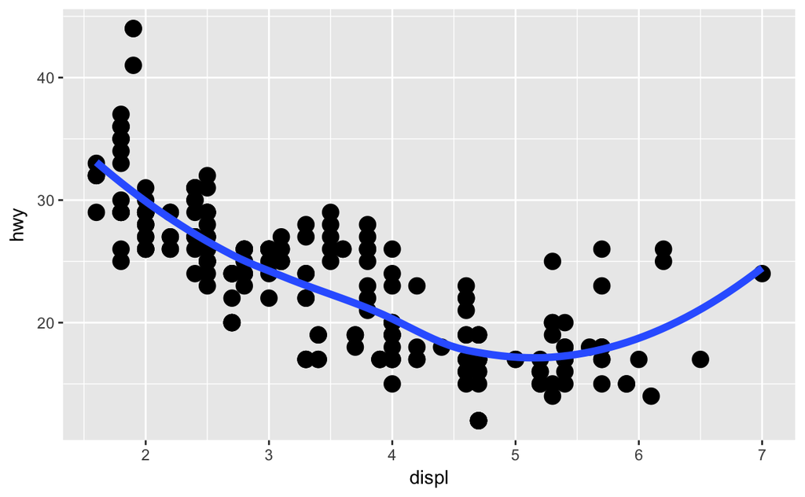

```r
# This can be simplified by mapping the aestheitcs in the ggplot()
ggplot(data = mpg, mapping = aes(x= displ, y = hwy)) +
  geom_point(size = 4) +
  geom_smooth(size = 2, se = FALSE)
```

## Graph 2—Top Right

The second graph shows the a regresion of the data by some factor (three of them) Drivetrain (drv) was used earlier in the document and matches the desired output.

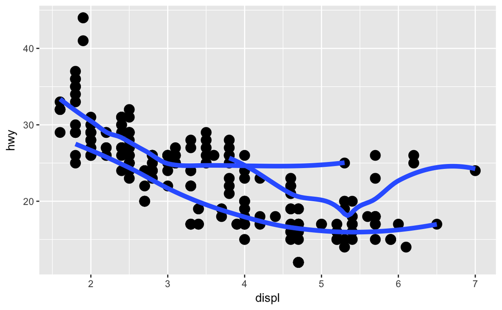

```r
ggplot(data = mpg, mapping = aes(x= displ, y = hwy)) +
  geom_point(size = 4) +
  geom_smooth(mapping = aes(group = drv), size = 2, se = FALSE)
```

## Graph 3—Middle Left

The middle left plot adds color to All the data colored by drivetrain:

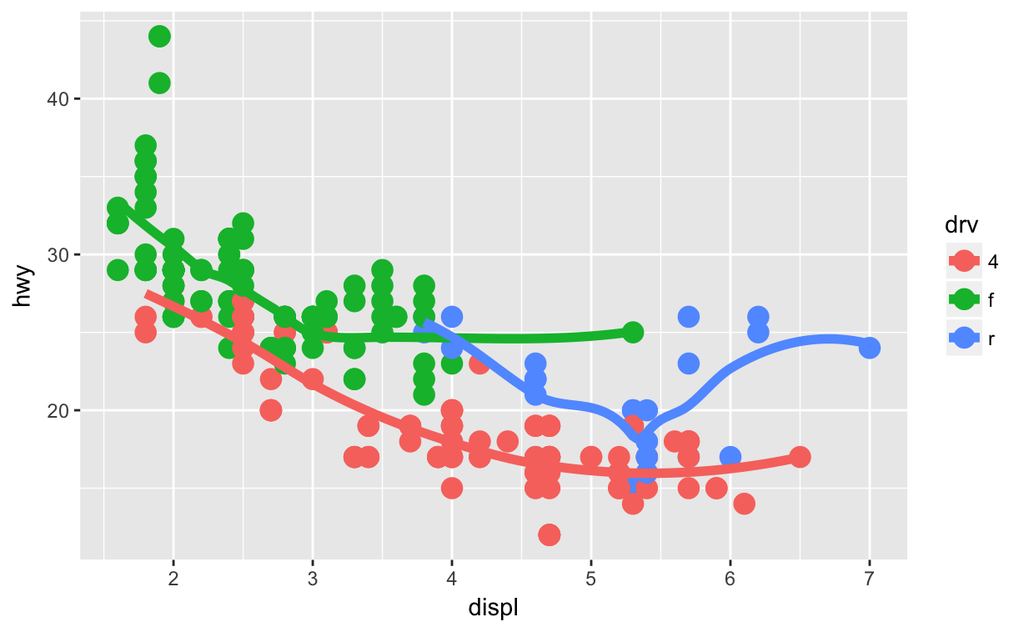

```r
ggplot(data = mpg, mapping = aes(x= displ, y = hwy, colour = drv)) +
  geom_point(size = 4) +
  geom_smooth(mapping = aes(group = drv), size = 2, se = FALSE)
```

## Grah 4—Middle Right

If I want to only color the data points, I need to move the aes() back to the gopm_point() and geom_smooth() positions.

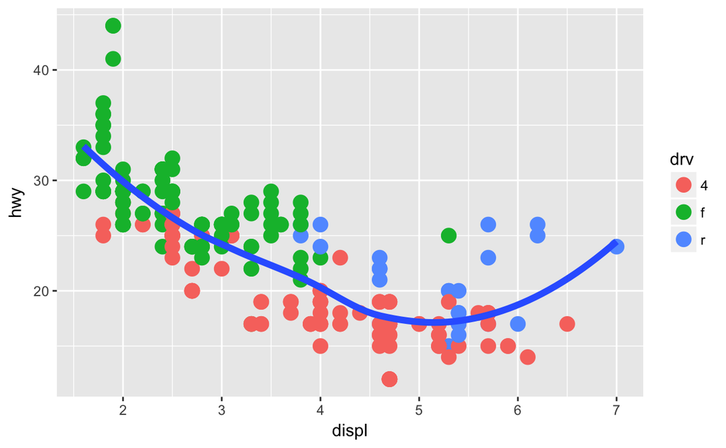

```r
ggplot(data = mpg) +
  geom_point(mapping = aes(x= displ, y = hwy, colour = drv), size = 4) +
  geom_smooth(mapping = aes(x= displ, y = hwy), size = 2, se = FALSE)
```

## Graph 5—Bottom Left

The bottom left requires we assign a *linetype* to each of the groups.

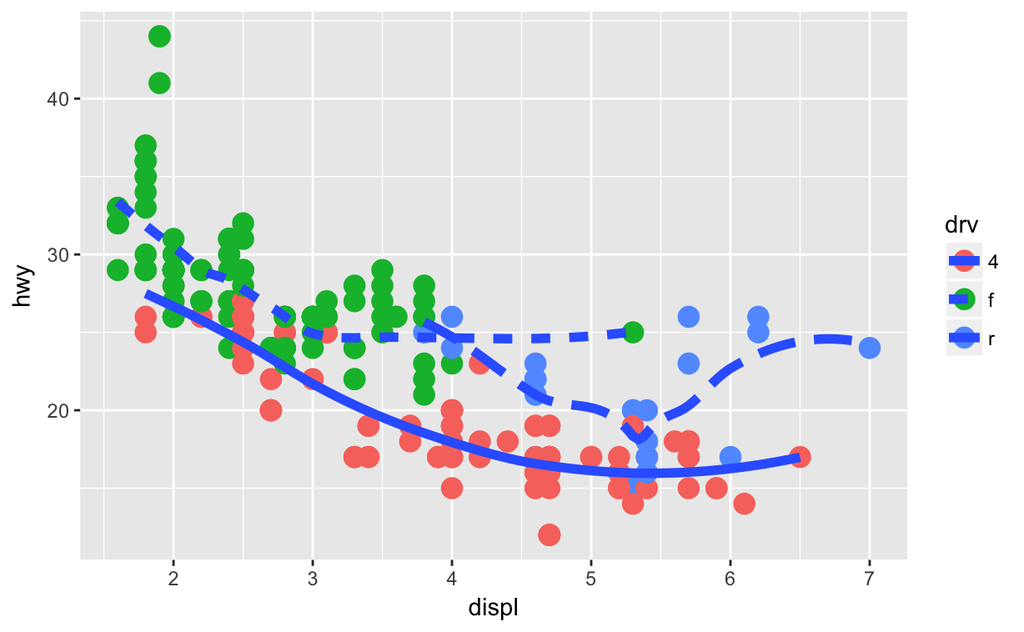

```r
ggplot(data = mpg) +
  geom_point(mapping = aes(x= displ, y = hwy, colour = drv), size = 4) +
  geom_smooth(mapping = aes(x= displ, y = hwy, linetype = drv), size = 2, se = FALSE)
```

## Graph 6—Bottom Right

I constructed the final graph by layering two sets of points using geom_point(). It looks to be plotting the colored points over a larger white point.

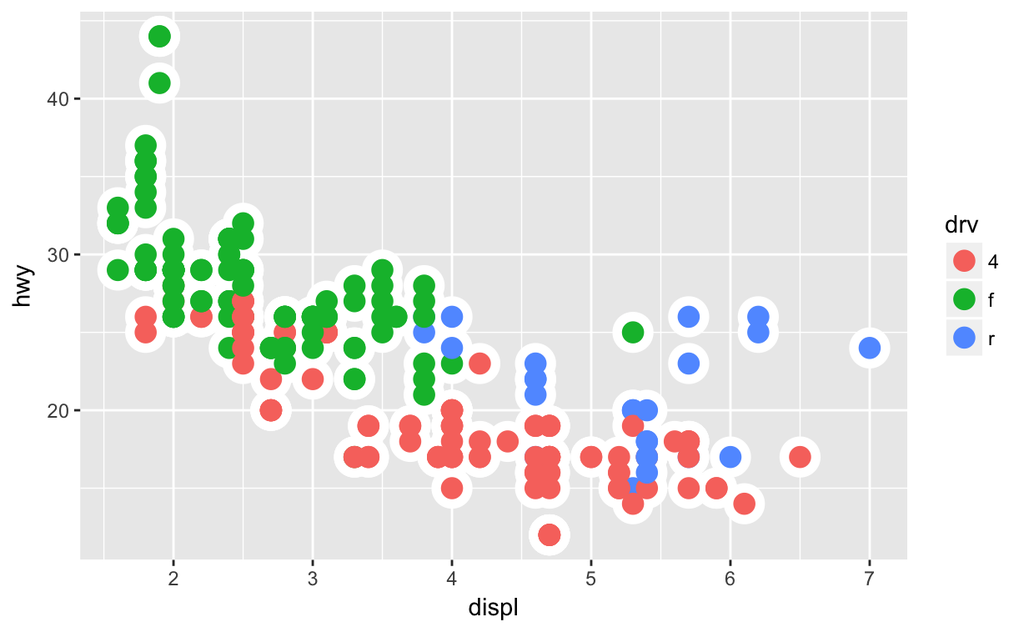

```r
ggplot(data = mpg) +
  geom_point(mapping = aes(x = displ, y = hwy), colour = "white", size = 8) +
  geom_point(mapping = aes(x = displ, y = hwy, colour = drv), size = 4)
```